# Uber Data Science Challenge

Xiaoyue Liu

November 6, 2016

```r
library(RJSONIO)
library(dplyr)
library(ggplot2)
library(corrplot)
library(glmnet)
library(randomForest)
```

## Part 1 - Exploratory data analysis

The attached logins.json file contains (simulated) timestamps of user logins in a particular geographic location.

- First load the data. The .json file contains the login timestamps. I’m going to analyze the data in R. I read the .json file line by line and combined all the lines to a single string, preparing for next steps.

```r
login_fileName='new_logins (1).json'
login_singleString <- paste(readLines(login_fileName), collapse=" ")
```

- Using the fromJSON function in the RJSONIO package to convert the long string to an R object. Here I got a list object. Then I got the login time vector from the list.

```r
login_raw = fromJSON(login_singleString,method='C',unexpected.escape = 'skip')
login_time=login_raw[[1]]
```

- The element in vector login_time is character format. I converted it to datetime format. After that I cut the login timestamps into 15-minute intervals, preparing for aggregation.

```r
login_time=as.POSIXlt(login_time)
login_cut=cut(login_time,seq(min(login_time),max(login_time),by=900))
```

- Aggregate these login counts based on 15-minute time intervals.

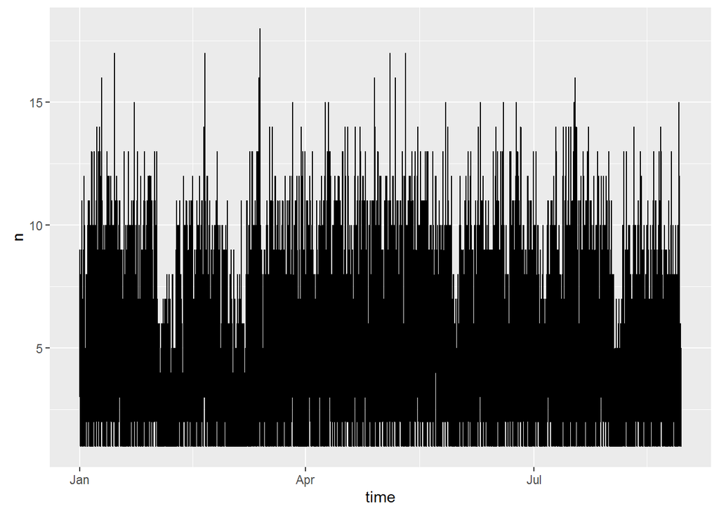

```r
login_gp=group_by(as.data.frame(login_cut),login_cut)
login_sum=summarize(login_gp,n=n())
login_sum=ungroup(login_sum)
login_sum$time=as.POSIXct(as.character(login_sum$login_cut))
ggplot(login_sum, aes(time, n)) + geom_line()
```

- Treat the login counts as a time series and analyze the spectrum.Here I chose the ‘ar’ method to smooth the spectrum.

```r
ts_login=ts(login_sum$n)
spectrum(ts_login,method='ar')
login_freq=as.data.frame(cbind(spectrum(ts_login,method='ar')$freq,
                              spectrum(ts_login,method='ar')$spec))
```

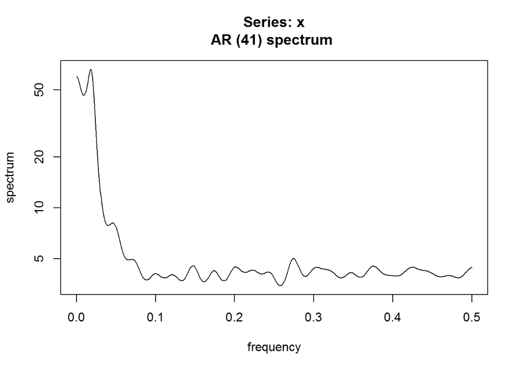

```r
names(login_freq)=c('freq','density')
head(login_freq,20)
```

```
##           freq  density
## 1  0.000000000 59.99639
## 2  0.001002004 59.52325
## 3  0.002004008 58.19442
## 4  0.003006012 56.24855
## 5  0.004008016 53.99456
## 6  0.005010020 51.73333
## 7  0.006012024 49.71005
## 8  0.007014028 48.10191
## 9  0.008016032 47.02856
## 10 0.009018036 46.57099
## 11 0.010020040 46.78883
## 12 0.011022044 47.73067
## 13 0.012024048 49.43341
## 14 0.013026052 51.90505
## 15 0.014028056 55.08155
## 16 0.015030060 58.74791
## 17 0.016032064 62.42812
## 18 0.017034068 65.30250
## 19 0.018036072 66.30141
## 20 0.019038076 64.52389
```

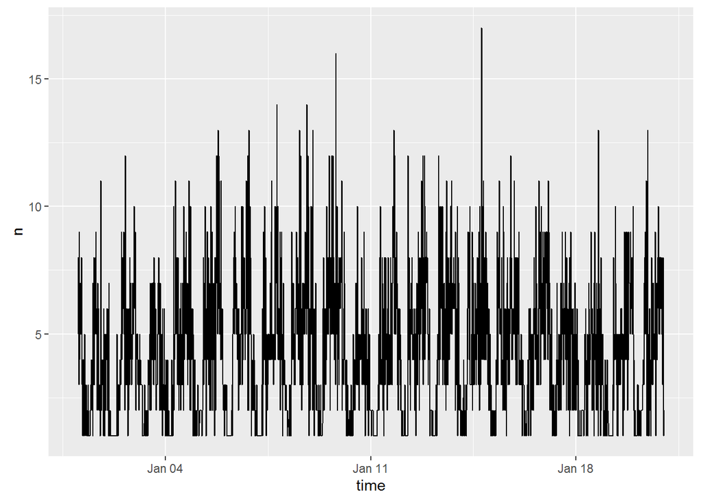

```r
ggplot(login_sum[login_sum$time<=as.POSIXct('2010-01-21'),], aes(time, n)) + geom_line()
```

- We can see that the daily cycle is obvious.The daily patterns are very similar,especially for weekdays. People use uber during rush hours (which is around 14 hours between home-to-work and work-to-home) on weekdays. And also people use uber more often during afternoons and evenings. On weekends, the uber demand is more spreaded during the whole day.

## Part 2 - Experiment and metrics design

**1. What would you choose as the key measure of success of this experiment in encouraging driver partners to serve both cities, and why would you choose this metric?**

Given that the purpose of proposed change is to encourge driver partners to serve both cities, the key measure of success should reflect an increase in the number of trips in Metropolis for driver partners from Gotham (and an increase in the number of trips in Gotham for driver partners from Metropolis). The KPI could be defined as the non-local trips per driver.

Non-local trips could be counted for each driver and averaged over conditions we are interested in. Drivers would be triggered into the experiment. The reimbursing could be notified after a certain ride, and the tracking time could be four weeks after the reimbursement notification. Then we can compute the non-local trips per driver during this time period.

**2. Describe a practical experiment you would design to compare the effectiveness of the proposed change in relation to the key measure of success. Please provide details on: a) how you will implement the experiment, b) what statistical test(s) you will conduct to verify the significance of the observation, and c) how you would interpret the results and provide recommendations to the city operations team along with any caveats.**

So the factors which could impact the non-local trips per driver are:1)with/without reimbursement;2)driver city-Gotham/Metropolis;3)time-day/night;4)which day-weekday/weekend.

2. I would use multi-factor ANOVA to verify the significance of the observation.
3. From the statistical test we can know whether the reimbursement is effective and how it is interacting with other variables we are interested in. The effect size would tell us how many more non-local trips are created by the reimbursement. Based on that then we can minimize our cost and optimize our profit. However, it is a risky experiment so that we may not want to waste too much money. We should balance between the experiment exposure rate and tracking time to satisfy the power condition. And also based on the city circadian rhythms:the solution could be like reimbursing toll cost from Gotham to Metropolis during the day and reimbursing toll cost from Metropolis to Gotham at night, and maybe only on weekdays. Before making the real decision, we should compute the added profit for different solutions based on the results of the ANOVA and optimize the profit according to the effects of the factors.

## Part 3 - Predictive modeling

- Data Cleaning, read the .json file and convert the data into an R object.

```r
fileName='uber_data_challenge.json'
singleString <- paste(readLines(fileName), collapse=" ")
uber_raw = fromJSON(singleString,method='C',unexpected.escape = 'skip')
uber_dat=NULL
for(i in 1:length(uber_raw))
{
  uber_dat=rbind(uber_dat,uber_raw[[i]])
}
uber_data=as.data.frame(uber_dat)
```

Convert the variables to proper format. Convert NULL to standard NA as missing values.

```r
##convert list to proper format
uber_data[,1] = as.factor(as.character(uber_data[,1]))
uber_data[,2] = as.numeric(as.character(uber_data[,2]))
uber_data[,3] = as.Date(as.character(uber_data[,3]))
uber_data[,4] = as.numeric(as.character(uber_data[,4]))
uber_data[,5] = as.numeric(as.character(uber_data[,5]))
uber_data[,6] = as.Date(as.character(uber_data[,6]))
uber_data[,7] = as.character(uber_data[,7])
uber_data[,7][uber_data[,7]=='NULL']=NA
uber_data[,7] = as.factor(uber_data[,7])
uber_data[,8] = as.numeric(as.character(uber_data[,8]))
uber_data[,9] = as.factor(as.character(uber_data[,9]))
uber_data[,10] = as.numeric(as.character(uber_data[,10]))
uber_data[,11] = as.numeric(as.character(uber_data[,11]))
uber_data[,12] = as.numeric(as.character(uber_data[,12]))
```

Creat the active indicator variable. Summary of the data. Save data set for future analysis.

```r
uber_data$active=as.numeric(uber_data$last_trip_date>=as.Date('2014-06-01'))
summary(uber_data)
```

```
##              city       trips_in_first_30_days  signup_date
##  Astapor       :16534   Min.   :  0.000        Min.   :2014-01-01
##  King's Landing:10130   1st Qu.:  0.000        1st Qu.:2014-01-09
##  Winterfell    :23336   Median :  1.000        Median :2014-01-17
##                         Mean   :  2.278        Mean   :2014-01-16
##                         3rd Qu.:  3.000        3rd Qu.:2014-01-24
##                         Max.   :125.000        Max.   :2014-01-31
##
##  avg_rating_of_driver   avg_surge     last_trip_date           phone
##  Min.   :1.000        Min.   :1.000   Min.   :2014-01-01   Android:15022
##  1st Qu.:4.300        1st Qu.:1.000   1st Qu.:2014-02-14   iPhone :34582
##  Median :4.900        Median :1.000   Median :2014-05-08   NA's   :  396
##  Mean   :4.602        Mean   :1.075   Mean   :2014-04-19
##  3rd Qu.:5.000        3rd Qu.:1.050   3rd Qu.:2014-06-18
##  Max.   :5.000        Max.   :8.000   Max.   :2014-07-01
##  NA's   :8122
##    surge_pct      uber_black_user  weekday_pct        avg_dist
##  Min.   :  0.00   FALSE:31146     Min.   :  0.00   Min.   :  0.000
##  1st Qu.:  0.00   TRUE :18854     1st Qu.: 33.30   1st Qu.:  2.420
##  Median :  0.00                   Median : 66.70   Median :  3.880
##  Mean   :  8.85                   Mean   : 60.93   Mean   :  5.797
##  3rd Qu.:  8.60                   3rd Qu.:100.00   3rd Qu.:  6.940
##  Max.   :100.00                   Max.   :100.00   Max.   :160.960
##
##  avg_rating_by_driver     active
##  Min.   :1.000        Min.   :0.0000
##  1st Qu.:4.700        1st Qu.:0.0000
##  Median :5.000        Median :0.0000
##  Mean   :4.778        Mean   :0.3761
##  3rd Qu.:5.000        3rd Qu.:1.0000
##  Max.   :5.000        Max.   :1.0000
##  NA's   :201
```

```r
write.csv(uber_data,file='uber_data_full.csv')
```

The fraction of the observed users who were retained is given here.

```r
mean(uber_data$active)
```

```
## [1] 0.37608
```

There are several columns with long tails. Let’s take a look at the box plots.

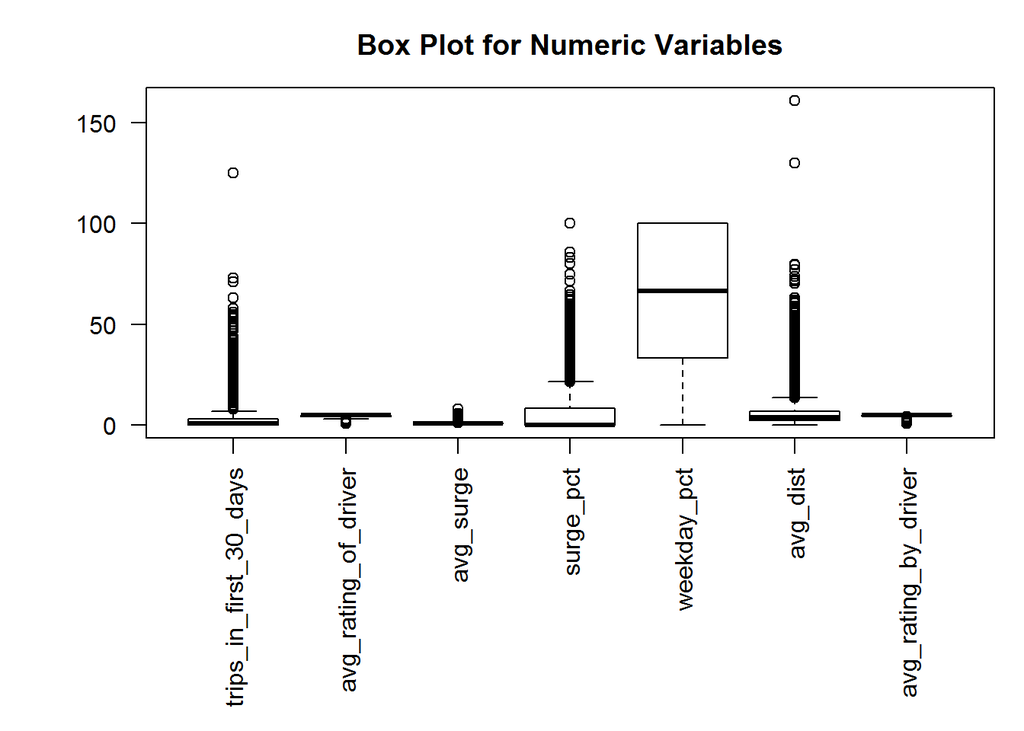

```r
par(mar=c(10,5,3,1))
boxplot(uber_data[,c(2,4,5,8,10,11,12)],las=2,main='Box Plot for Numeric Variables')
```

We can see that there are potential outliers in the variables, especially trips_in_first_30_days,surge_pct, and avg_dist.

Then we can take a look at the correlation among the variables. We can see that there exist certain degree of correlation between variable pairs, considering it is a large data set. However the avg_surge and surge_pct are highly correlated, we should consider the interaction between them.

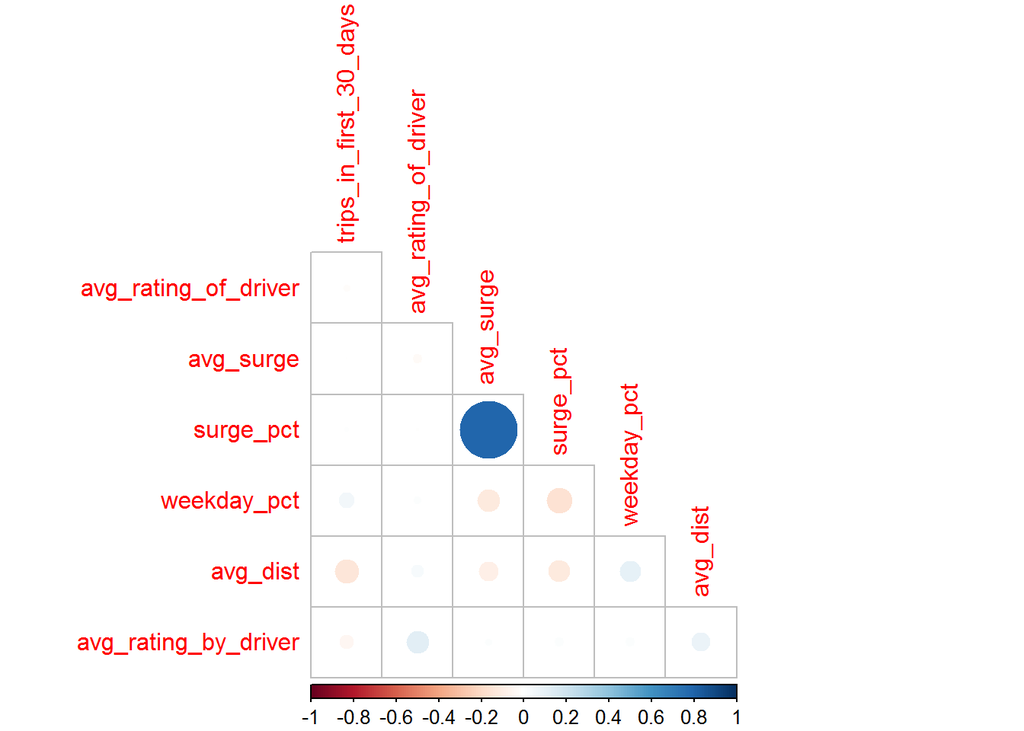

```r
M=cor(na.omit(uber_data[,c(2,4,5,8,10,11,12)]),use="pairwise.complete.obs")
corrplot::corrplot(M, method="circle", type="lower", diag=F)
```

There are 8122 records that are missing values for avg_rating_of_driver, and some missing values for phone and avg_rating_by_driver. Also there are some users with avg_dist as 0, which does not make much sense. Some findings are: if avg_rating_of_driver is NA, then there is a large probability that the user is not active.And also they have 0 or 1 trip in the first 30 days. This shows that the missing is not at random. The missing may be because the user was not active in very early period after sign up.

```r
sum(uber_data$active==0&is.na(uber_data$avg_rating_of_driver))
```

```
## [1] 6490
```

```r
sum(uber_data$trips_in_first_30_days<=1&is.na(uber_data$avg_rating_of_driver))
```

```
## [1] 7736
```

## Main Models

```r
uber_data=read.csv(file='uber_data_full.csv',header=T)
uber_data=na.omit(uber_data[,-c(1,4,7)])
##Label the outliers
uber_data$trips_in_first_30_days.high=uber_data$trips_in_first_30_days>2.61+1.5*(3-0)
uber_data$avg_rating_of_driver.low=uber_data$avg_rating_of_driver<4.6-1.5*(5-4.3)
uber_data$avg_surge.high=uber_data$avg_surge>1.074+1.5*(1.070-1)
uber_data$surge_pct.high=uber_data$surge_pct>8.899+1.5*(11.1-0)
uber_data$avg_dist.high=uber_data$avg_dist>5.46+1.5*(6.49-2.42)
uber_data$avg_rating_by_driver.low=uber_data$avg_rating_by_driver<4.776-1.5*(5-4.7)
```

**Training/Test Data Set** I used a 90% random sample to be the training set,and use the rest 10% as test set.

```r
set.seed(7)
m = dim(uber_data)[1]
training_id = sample(m,floor(0.9*m), replace = FALSE)
y=uber_data$active
y.training=y[training_id]
y.test=y[-training_id]
uber_lasso=as.data.frame(cbind(y,uber_data[,-11]))
uber_lasso = model.matrix(y ~., data = uber_lasso)
uber_lasso = as.matrix(data.frame(uber_lasso))[,-1]
training = uber_lasso[training_id,]
test = uber_lasso[-training_id,]
```

**Fitting the Model**

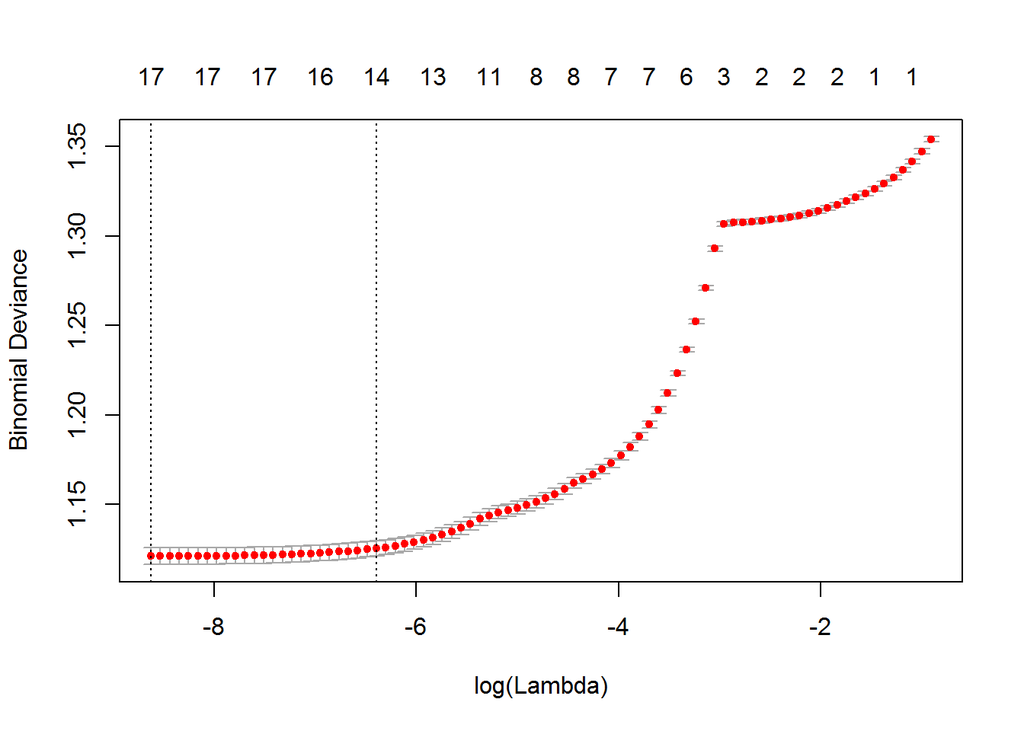

```r
cvfit = cv.glmnet(x = training, y=as.factor(y[training_id]), family = 'binomial', standardize=FALSE)
plot(cvfit)
```

**Odds Ratios**

```r
exp(coef(cvfit, s = "lambda.min"))
```

```
## 18 x 1 Matrix of class "dgeMatrix"
##                                          1
## (Intercept)                     14.9467707
## cityKing.s.Landing               5.6696644
## cityWinterfell                   1.6943710
## trips_in_first_30_days           1.0799522
## avg_rating_of_driver             0.7888385
## avg_surge                        0.6856827
## phoneiPhone                      2.9718371
## surge_pct                        1.0149056
## uber_black_userTRUE              2.4859279
## weekday_pct                      0.9996978
## avg_dist                         0.9975309
## avg_rating_by_driver             0.4885256
## trips_in_first_30_days.highTRUE  1.2722562
## avg_rating_of_driver.lowTRUE     0.5404725
## avg_surge.highTRUE               1.2841245
## surge_pct.highTRUE               0.4025687
## avg_dist.highTRUE                0.4828776
## avg_rating_by_driver.lowTRUE     0.3813634
```

**Prediction Performance**

```r
y.hat = predict(cvfit, test, s = "lambda.min", type = "response")
y.hat= ifelse(y.hat>0.45, 1, 0)
pred.active=y.hat
true.active=y[-training_id]
sum(y.hat==y[-training_id])/length(y.hat)
```

```
## [1] 0.6991556
```

```r
table(pred.active, true.active)
```

```
##            true.active
## pred.active    0    1
##           0 1847  669
##           1  578 1051
```

```r
prop.table(xtabs(~ pred.active + true.active), margin=2)
```

```
##            true.active
## pred.active         0         1
##           0 0.7616495 0.3889535
##           1 0.2383505 0.6110465
```

The confusion matrix and accuracy table are listed above. This model is good at predicting riders who will drop out during the 6 months. However it is not very good in predicting riders who will retain active.

## Random Forest Approach

```r
training2 = uber_data[training_id,]
training2 = as.data.frame(training2)
test2 = uber_data[-training_id,]
test2 = as.data.frame(test2)
model = randomForest(active~., data = training2, mtry = 6, ntree = 200)
ranking = importance(model)
```

Prediction Performance

```r
active.hat = predict(model, test2[,-11], type = "response")
active.hat = ifelse(active.hat>0.45, 1, 0)
sum(active.hat==test2$active)/length(active.hat)
```

```
## [1] 0.7633293
```

```r
table(active.hat, test2$active)
```

```
##
## active.hat    0    1
##          0 1933  489
##          1  492 1231
```

```r
prop.table(xtabs(~ active.hat + test2$active), margin=2)
```

```
##           test2$active
## active.hat         0         1
##          0 0.7971134 0.2843023
##          1 0.2028866 0.7156977
```

The confusion matrix and accuracy table are listed above. We can see that random forest has a better prediction performance in predicting the riders who will retain.

**Briefly discuss how Uber might leverage the insights gained from the model to improve its rider retention.**

All other things being equal, being from King’s Landing increases the odds of an active user to 5.67 times, which King’s Landing is a better market for Uber compared to Astapor. Also Winterfell is a better market than Astapor. Next is the phone, we can see user using Iphone will increase the odds of an active user to 2.97 times,this may be realated to the App experience, we may pay more attention here. Uber black users has a odds of being an active user 2.49 times non uber black users, showing uber black users are more loyal to Uber. High trips_in_first_30_days would increase the odds of an active user to 1.27 times, so that a considerable trips_in_first_30_days could be a indicator of future retention. And we can see that high surge_pct will decrease the odds of an active user to 0.40 times, also high avg_dist will decrease the odds of an active user to 0.48 times, that is because Uber costs much for those people. And low avg_rating_of_driver will decrease the odds of an active user to 0.54 times,low avg_rating_by_driver will decrease the odds of an active user to 0.38 times,this indicates bad ride experience. There is some payoff between high avg_surge and high surge_pct since no user would like to be extreme on both variables.

If we want to look into details of the effect of any single factor, we could use counterfactual approach or propensity score matching to get rid of the Simpson’s paradox.